# A quick tour of **mclust**

Luca Scrucca

27 Jun 2018

# Introduction

**mclust** is a contributed R package for model-based clustering, classification, and density estimation based on finite normal mixture modelling. It provides functions for parameter estimation via the EM algorithm for normal mixture models with a variety of covariance structures, and functions for simulation from these models. Also included are functions that combine model-based hierarchical clustering, EM for mixture estimation and the Bayesian Information Criterion (BIC) in comprehensive strategies for clustering, density estimation and discriminant analysis. Additional functionalities are available for displaying and visualizing fitted models along with clustering, classification, and density estimation results.

This document gives a quick tour of **mclust** (version 5.4.1) functionalities. It was written in R Markdown, using the knitr package for production. See `help(package="mclust")` for further details and references provided by `citation("mclust")`.

```r
library(mclust)
```

# Clustering

```r
data(diabetes)
class <- diabetes$class
table(class)
## class
## Chemical   Normal    Overt
##       36       76       33
X <- diabetes[,-1]
head(X)
```

```
##   glucose insulin sspg
## 1      80     356  124
## 2      97     289  117
## 3     105     319  143
## 4      90     356  199
## 5      90     323  240
## 6      86     381  157
```

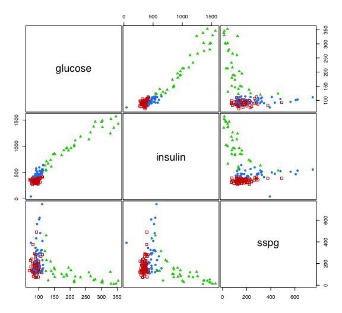

```r
clPairs(X, class)
```

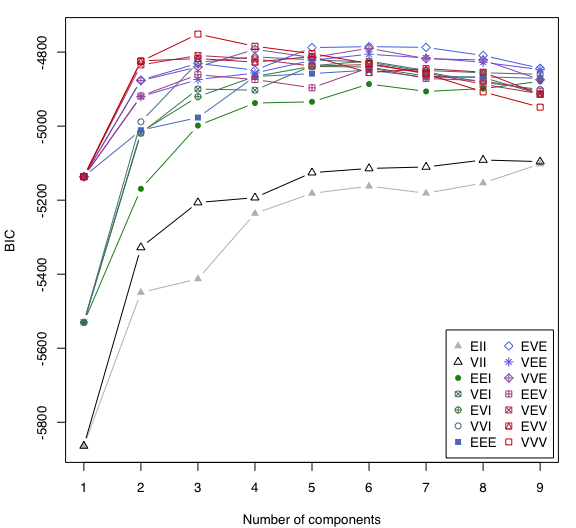

```r
BIC <- mclustBIC(X)
plot(BIC)
```

```r
summary(BIC)
## Best BIC values:
##              VVV,3       VVV,4       EVE,6
## BIC      -4751.316 -4784.32213 -4785.24591
## BIC diff     0.000   -33.00573   -33.92951

mod1 <- Mclust(X, x = BIC)
summary(mod1, parameters = TRUE)
```

```
## ----------------------------------------------------
## Gaussian finite mixture model fitted by EM algorithm
## ----------------------------------------------------
##
## Mclust VVV (ellipsoidal, varying volume, shape, and orientation) model
## with 3 components:
##
##  log.likelihood   n df       BIC       ICL
##       -2303.496 145 29 -4751.316 -4770.169
##
## Clustering table:
##  1  2  3
## 81 36 28
##
## Mixing probabilities:
##         1         2         3
## 0.5368974 0.2650129 0.1980897
##
## Means:
##              [,1]     [,2]       [,3]
## glucose  90.96239 104.5335  229.42136
## insulin 357.79083 494.8259 1098.25990
## sspg    163.74858 309.5583   81.60001
##
## Variances:
## [,,1]
##          glucose    insulin       sspg
## glucose 57.18044   75.83206   14.73199
## insulin 75.83206 2101.76553  322.82294
## sspg    14.73199  322.82294 2416.99074
## [,,2]
##           glucose   insulin       sspg
## glucose  185.0290  1282.340  -509.7313
## insulin 1282.3398 14039.283 -2559.0251
## sspg    -509.7313 -2559.025 23835.7278
## [,,3]
##           glucose   insulin       sspg
## glucose  5529.250  20389.09  -2486.208
## insulin 20389.088  83132.48 -10393.004
## sspg    -2486.208 -10393.00   2217.533
```

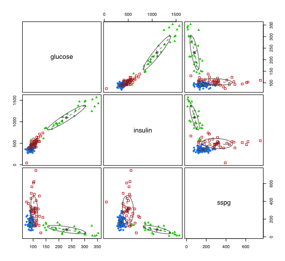

```r
plot(mod1, what = "classification")
```

```r
table(class, mod1$classification)
```

```
##
## class       1  2  3
##   Chemical  9 26  1
##   Normal   72  4  0
##   Overt     0  6 27
```

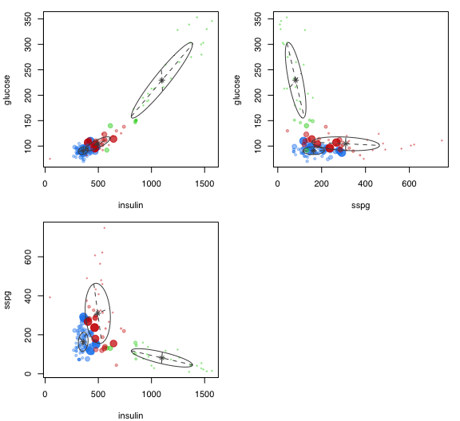

```r
par(mfrow = c(2,2))
plot(mod1, what = "uncertainty", dimens = c(2,1), main = "")
plot(mod1, what = "uncertainty", dimens = c(3,1), main = "")
plot(mod1, what = "uncertainty", dimens = c(2,3), main = "")
par(mfrow = c(1,1))
```

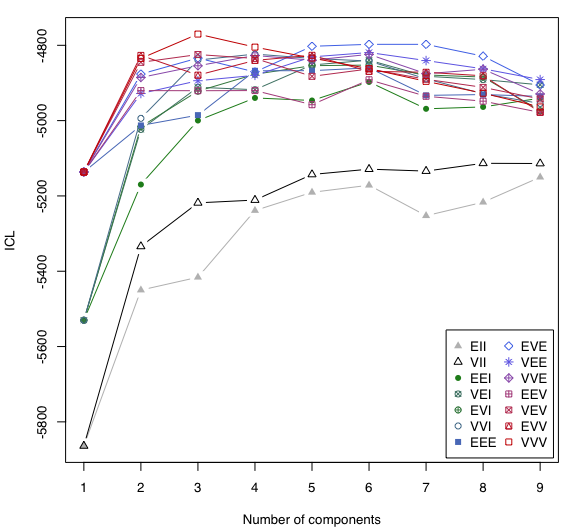

```r
ICL <- mclustICL(X)
summary(ICL)
## Best ICL values:
##              VVV,3       EVE,6       EVE,7
## ICL      -4770.169 -4797.38232 -4797.50566
## ICL diff     0.000   -27.21342   -27.33677
plot(ICL)
```

```r
LRT <- mclustBootstrapLRT(X, modelName = "VVV")
LRT
```

```
## -------------------------------------------------------------
## Bootstrap sequential LRT for the number of mixture components
## -------------------------------------------------------------
## Model        = VVV
## Replications = 999
##               LRTS bootstrap p-value
## 1 vs 2   361.16739             0.001
## 2 vs 3   123.49685             0.001
## 3 vs 4    16.76161             0.502
```

# Classification

## EDDA

```r
data(iris)
class <- iris$Species
table(class)
## class
##     setosa versicolor  virginica
##         50         50         50
X <- iris[,1:4]
head(X)
```

```
##   Sepal.Length Sepal.Width Petal.Length Petal.Width
## 1          5.1         3.5          1.4         0.2
## 2          4.9         3.0          1.4         0.2
## 3          4.7         3.2          1.3         0.2
## 4          4.6         3.1          1.5         0.2
## 5          5.0         3.6          1.4         0.2
## 6          5.4         3.9          1.7         0.4
```

```r
mod2 <- MclustDA(X, class, modelType = "EDDA")
summary(mod2)
```

```
## ------------------------------------------------
## Gaussian finite mixture model for classification
## ------------------------------------------------
##
## EDDA model summary:
##
##  log.likelihood   n df       BIC
##       -187.7097 150 36 -555.8024
##
## Classes       n Model G
##   setosa     50   VEV 1
##   versicolor 50   VEV 1
##   virginica  50   VEV 1
##
## Training classification summary:
##
##             Predicted
## Class        setosa versicolor virginica
##   setosa         50          0         0
##   versicolor      0         47         3
##   virginica       0          0        50
##
## Training error = 0.02
```

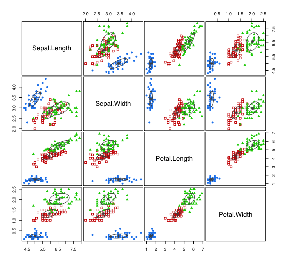

```r
plot(mod2, what = "scatterplot")
```

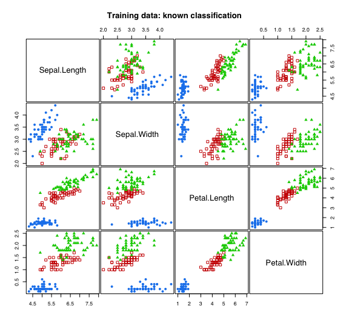

```r
plot(mod2, what = "classification")
```

## MclustDA

```r
data(banknote)
class <- banknote$Status
table(class)
## class
## counterfeit     genuine
##         100         100
X <- banknote[,-1]
head(X)
```

```
##   Length  Left Right Bottom  Top Diagonal
## 1  214.8 131.0 131.1    9.0  9.7    141.0
## 2  214.6 129.7 129.7    8.1  9.5    141.7
## 3  214.8 129.7 129.7    8.7  9.6    142.2
## 4  214.8 129.7 129.6    7.5 10.4    142.0
## 5  215.0 129.6 129.7   10.4  7.7    141.8
## 6  215.7 130.8 130.5    9.0 10.1    141.4
```

```r
mod3 <- MclustDA(X, class)
summary(mod3)
```

```
## ------------------------------------------------
## Gaussian finite mixture model for classification
## ------------------------------------------------
##
## MclustDA model summary:
##
##  log.likelihood   n df       BIC
##       -646.0798 200 66 -1641.849
##
## Classes         n Model G
##   counterfeit 100   EVE 2
##   genuine     100   XXX 1
##
## Training classification summary:
##
##              Predicted
## Class         counterfeit genuine
##   counterfeit         100       0
##   genuine               0     100
##
## Training error = 0
```

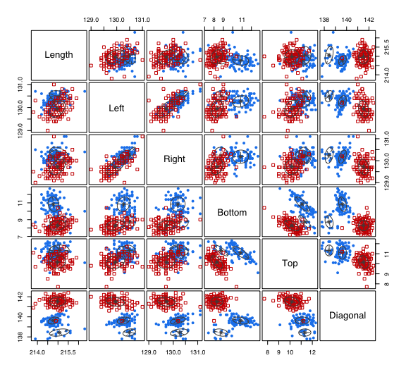

```r
plot(mod3, what = "scatterplot")
```

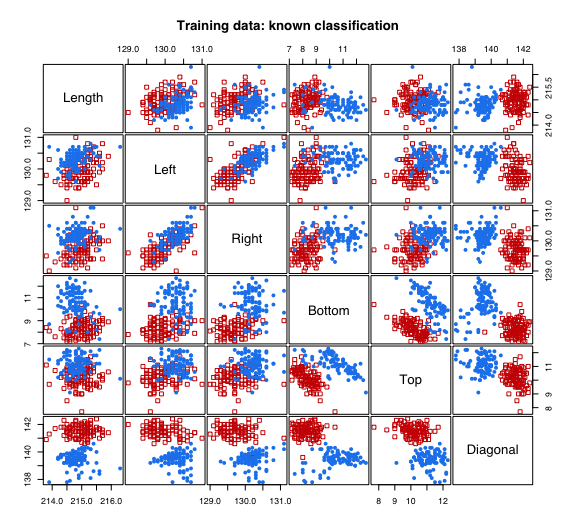

```r
plot(mod3, what = "classification")
```

## Cross-validation error

```r
cv <- cvMclustDA(mod2, nfold = 10)
str(cv)
```

```
## List of 4
##  $ classification: Factor w/ 3 levels "setosa","versicolor",..: 1 1 1 1 1 1 1 1 1 1 ...
##  $ z             : num [1:150, 1:3] 1 1 1 1 1 1 1 1 1 1 ...
##  $ error         : num 0.0267
##  $ se            : num 0.0109
```

```r
unlist(cv[3:4])
```

```
##      error         se
## 0.02666667 0.01088662
```

```r
cv <- cvMclustDA(mod3, nfold = 10)
str(cv)
```

```
## List of 4
##  $ classification: Factor w/ 2 levels "counterfeit",..: 2 2 2 2 2 2 2 2 2 2 ...
##  $ z             : num [1:200, 1:2] 2.33e-05 3.20e-20 1.05e-26 1.41e-20 3.64e-18 ...
##  $ error         : num 0
##  $ se            : num 0
```

```r
unlist(cv[3:4])
## error    se
##     0     0
```

# Density estimation

## Univariate

```r
data(acidity)
mod4 <- densityMclust(acidity)
summary(mod4)
```

```
## -------------------------------------------------------
## Density estimation via Gaussian finite mixture modeling
## -------------------------------------------------------
##
## Mclust E (univariate, equal variance) model with 2 components:
##
##  log.likelihood   n df       BIC       ICL
##       -185.9493 155  4 -392.0723 -398.5554
##
## Clustering table:
##  1  2
## 98 57
```

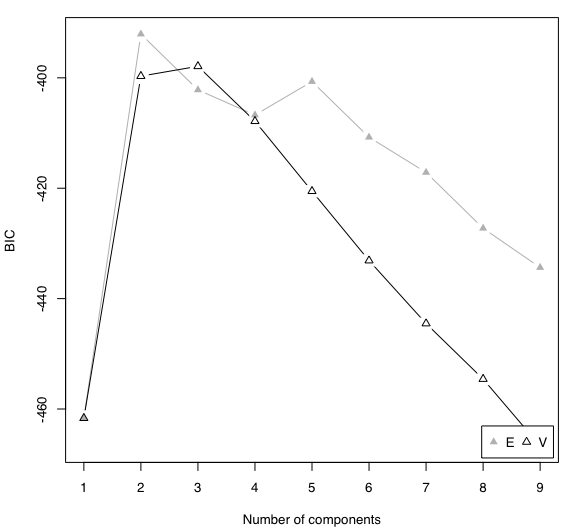

```r
plot(mod4, what = "BIC")
```

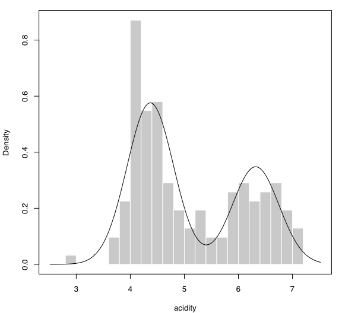

```r
plot(mod4, what = "density", data = acidity, breaks = 15)
```

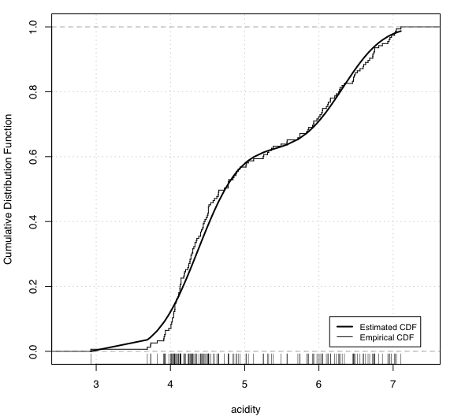

```r
plot(mod4, what = "diagnostic", type = "cdf")
```

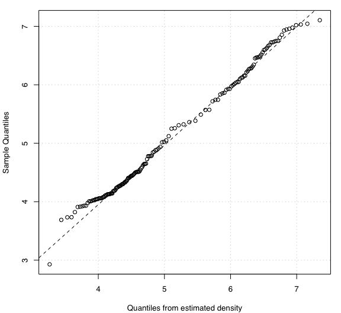

```r
plot(mod4, what = "diagnostic", type = "qq")
```

## Multivariate

```r
data(faithful)
mod5 <- densityMclust(faithful)
summary(mod5)
```

```
## -------------------------------------------------------
## Density estimation via Gaussian finite mixture modeling
## -------------------------------------------------------
##
## Mclust EEE (ellipsoidal, equal volume, shape and orientation) model with 3
## components:
##
##  log.likelihood   n df       BIC       ICL
##       -1126.326 272 11 -2314.316 -2357.824
##
## Clustering table:
##   1   2   3
##  40  97 135
```

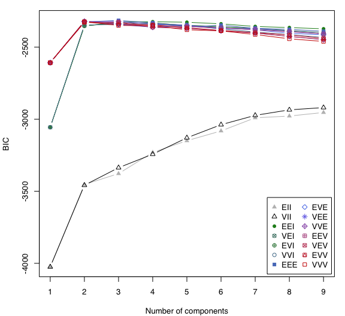

```r
plot(mod5, what = "BIC")
```

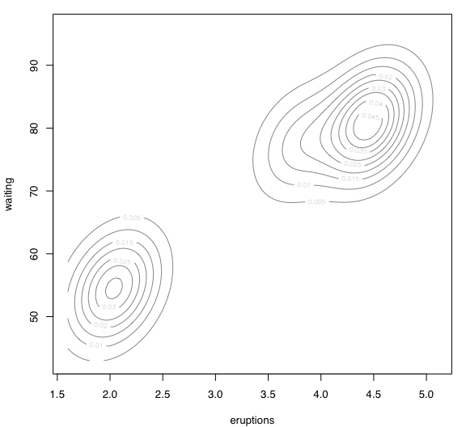

```r
plot(mod5, what = "density")
```

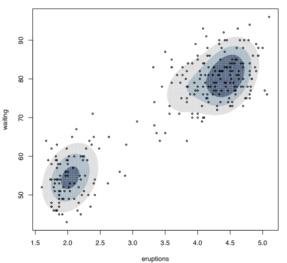

```r
plot(mod5, what = "density", type = "level")
plot(mod5, what = "density", type = "level",
     data = faithful, points.cex = 0.5)
```

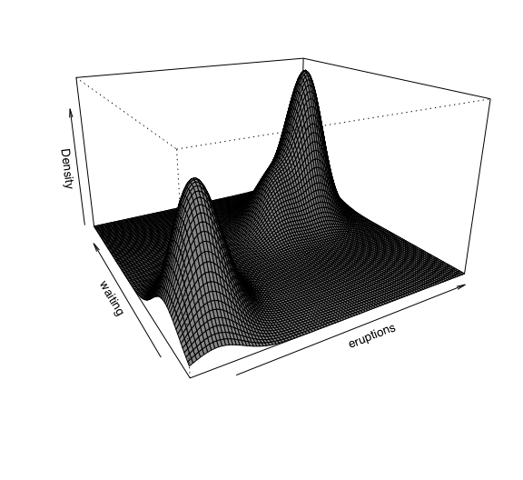

```r
plot(mod5, what = "density", type = "persp")
```

# Bootstrap inference

```r
boot1 <- MclustBootstrap(mod1, nboot = 999, type = "bs")
summary(boot1, what = "se")
```

```
## ----------------------------------------------------------
## Resampling standard errors
## ----------------------------------------------------------
## Model                      = VVV
## Num. of mixture components = 3
## Replications               = 999
## Type                       = nonparametric bootstrap
##
## Mixing probabilities:
##          1          2          3
## 0.05157691 0.05166146 0.03441169
##
## Means:
##                1         2        3
## glucose 1.030304  3.288285 16.85325
## insulin 7.602664 28.472941 67.26101
## sspg    8.017345 31.453195 10.07305
##
## Variances:
## [,,1]
##          glucose   insulin      sspg
## glucose 10.65030  51.23503  50.97503
## insulin 51.23503 509.57372 403.54544
## sspg    50.97503 403.54544 635.65812
## [,,2]
##           glucose   insulin      sspg
## glucose  66.74676  632.3578  428.8158
## insulin 632.35780 7408.7968 3135.7059
## sspg    428.81584 3135.7059 6737.3234
## [,,3]
##           glucose   insulin      sspg
## glucose 1012.6054  4130.902  643.2742
## insulin 4130.9015 18842.401 2456.0913
## sspg     643.2742  2456.091  464.8030
```

```r
summary(boot1, what = "ci")
```

```
## ----------------------------------------------------------
## Resampling confidence intervals
## ----------------------------------------------------------
## Model                      = VVV
## Num. of mixture components = 3
## Replications               = 999
## Type                       = nonparametric bootstrap
## Confidence level           = 0.95
##
## Mixing probabilities:
##               1         2         3
## 2.5%  0.4427278 0.1526047 0.1323351
## 97.5% 0.6505815 0.3533016 0.2660190
##
## Means:
## [,,1]
##        glucose  insulin     sspg
## 2.5%  89.16707 344.0819 150.0530
## 97.5% 93.03161 374.1667 181.0166
## [,,2]
##         glucose  insulin     sspg
## 2.5%   98.87092 448.0427 257.9645
## 97.5% 111.57315 556.0413 387.3176
## [,,3]
##        glucose   insulin      sspg
## 2.5%  196.4655  961.9813  61.51167
## 97.5% 261.5179 1221.7314 100.97944
##
## Variances:
## [,,1]
##        glucose  insulin     sspg
## 2.5%  38.18567 1251.429 1520.231
## 97.5% 81.13104 3233.066 4036.832
## [,,2]
##         glucose   insulin     sspg
## 2.5%   87.81592  3321.645 12016.20
## 97.5% 371.37111 31078.672 38467.24
## [,,3]
##        glucose   insulin     sspg
## 2.5%  3458.671  44984.51 1342.351
## 97.5% 7419.122 120789.09 3079.338
```

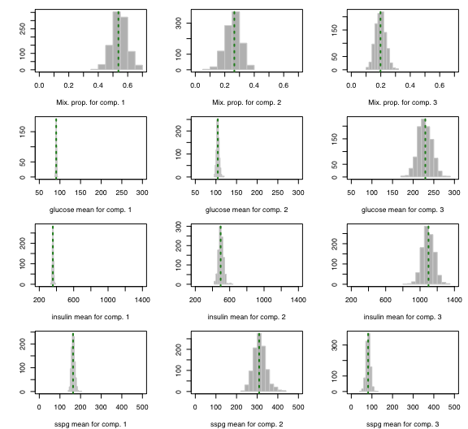

```r
par(mfrow=c(4,3))
plot(boot1, what = "pro")
plot(boot1, what = "mean")
```

```r
par(mfrow=c(1,1))
```

```r
boot4 <- MclustBootstrap(mod4, nboot = 999, type = "bs")
summary(boot4, what = "se")
```

```
## ----------------------------------------------------------
## Resampling standard errors
## ----------------------------------------------------------
## Model                      = E
## Num. of mixture components = 2
## Replications               = 999
## Type                       = nonparametric bootstrap
##
## Mixing probabilities:
##          1          2
## 0.04085973 0.04085973
##
## Means:
##          1          2
## 0.04301080 0.06841225
##
## Variances:
##          1          2
## 0.02395481 0.02395481
```

```r
summary(boot4, what = "ci")
```

```
## ----------------------------------------------------------
## Resampling confidence intervals
## ----------------------------------------------------------
## Model                      = E
## Num. of mixture components = 2
## Replications               = 999
## Type                       = nonparametric bootstrap
## Confidence level           = 0.95
##
## Mixing probabilities:
##               1         2
## 2.5%  0.5457536 0.2986114
## 97.5% 0.7013886 0.4542464
##
## Means:
##              1        2
## 2.5%  4.284239 6.183910
## 97.5% 4.451932 6.453272
##
## Variances:
##               1         2
## 2.5%  0.1419977 0.1419977
## 97.5% 0.2358523 0.2358523
```

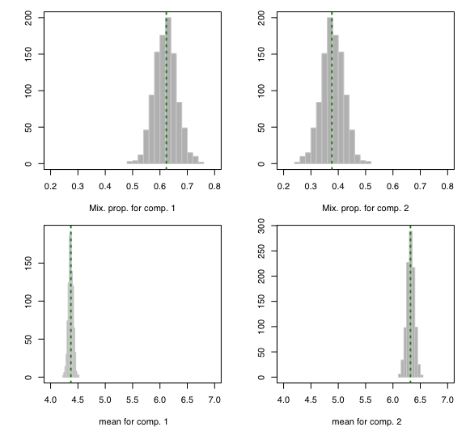

```r
par(mfrow=c(2,2))
plot(boot4, what = "pro")
plot(boot4, what = "mean")
```

```r
par(mfrow=c(1,1))
```

# Dimension reduction

## Clustering

```r
mod1dr <- MclustDR(mod1)
summary(mod1dr)
```

```
## -----------------------------------------------------------------
## Dimension reduction for model-based clustering and classification
## -----------------------------------------------------------------
##
## Mixture model type: Mclust (VVV, 3)
##
## Clusters  n
##        1 81
##        2 36
##        3 28
##
## Estimated basis vectors:
##              Dir1     Dir2      Dir3
## glucose -0.988671  0.76532 -0.966565
## insulin  0.142656 -0.13395  0.252109
## sspg    -0.046689  0.62955  0.046837
##
##                Dir1     Dir2      Dir3
## Eigenvalues  1.3506  0.75608   0.53412
## Cum. %      51.1440 79.77436 100.00000
```

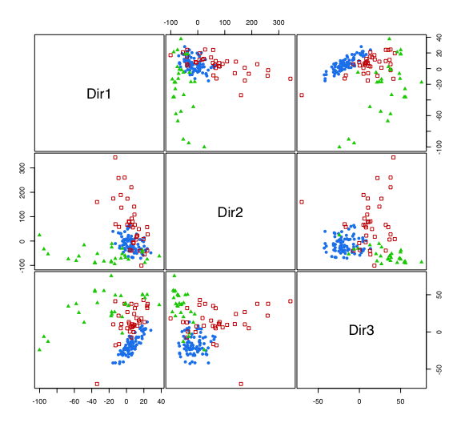

```r
plot(mod1dr, what = "pairs")
```

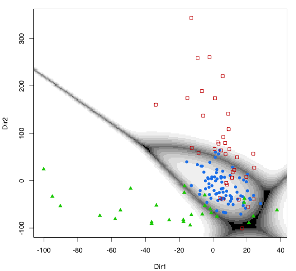

```r
plot(mod1dr, what = "boundaries", ngrid = 200)
```

```r
mod1dr <- MclustDR(mod1, lambda = 1)
summary(mod1dr)
```

```
## -----------------------------------------------------------------
## Dimension reduction for model-based clustering and classification
## -----------------------------------------------------------------
##
## Mixture model type: Mclust (VVV, 3)
##
## Clusters  n
##        1 81
##        2 36
##        3 28
##
## Estimated basis vectors:
##              Dir1     Dir2
## glucose  0.764699  0.86359
## insulin -0.643961 -0.22219
## sspg     0.023438 -0.45260
##
##                Dir1      Dir2
## Eigenvalues  1.2629   0.35218
## Cum. %      78.1939 100.00000
```

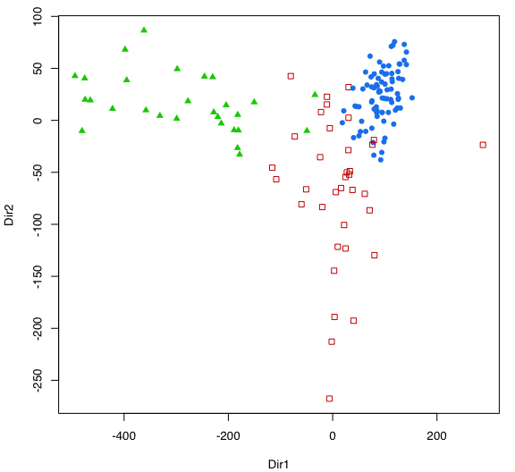

```r
plot(mod1dr, what = "scatterplot")
```

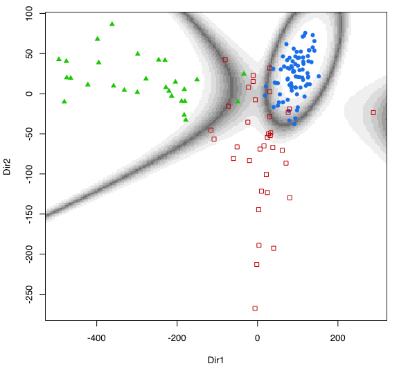

```r
plot(mod1dr, what = "boundaries", ngrid = 200)
```

## Classification

```r
mod2dr <- MclustDR(mod2)
summary(mod2dr)
```

```
## -----------------------------------------------------------------
## Dimension reduction for model-based clustering and classification
## -----------------------------------------------------------------
##
## Mixture model type: EDDA
##
## Classes       n Model G
##   setosa     50   VEV 1
##   versicolor 50   VEV 1
##   virginica  50   VEV 1
##
## Estimated basis vectors:
##                  Dir1      Dir2     Dir3     Dir4
## Sepal.Length  0.17425 -0.193663  0.64081 -0.46231
## Sepal.Width   0.45292  0.066561  0.34852  0.57110
## Petal.Length -0.61629 -0.311030 -0.42366  0.46256
## Petal.Width  -0.62024  0.928076  0.53703 -0.49613
##
##                 Dir1     Dir2      Dir3       Dir4
## Eigenvalues  0.94747  0.68835  0.076141   0.052607
## Cum. %      53.69408 92.70374 97.018700 100.000000
```

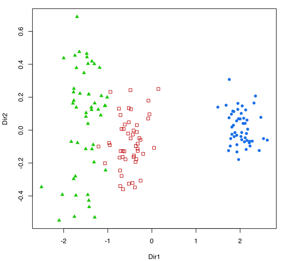

```r
plot(mod2dr, what = "scatterplot")
```

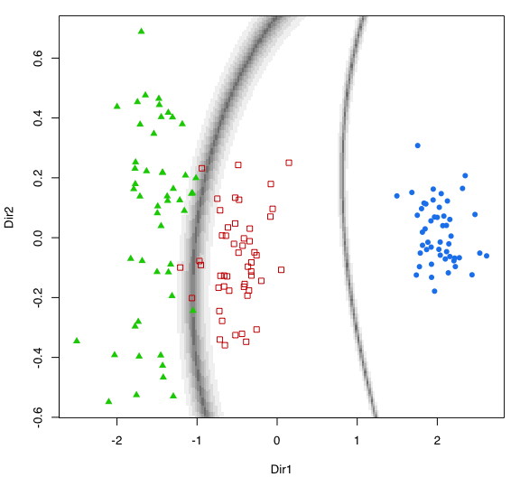

```r
plot(mod2dr, what = "boundaries", ngrid = 200)
```

```r
mod3dr <- MclustDR(mod3)
summary(mod3dr)
```

```
## -----------------------------------------------------------------
## Dimension reduction for model-based clustering and classification
## -----------------------------------------------------------------
##
## Mixture model type: MclustDA
##
## Classes         n Model G
##   counterfeit 100   EVE 2
##   genuine     100   XXX 1
##
## Estimated basis vectors:
##              Dir1      Dir2     Dir3      Dir4      Dir5      Dir6
## Length   -0.10027 -0.327553  0.79718 -0.033721 -0.317043  0.084618
## Left     -0.21760 -0.305350 -0.30266 -0.893676  0.371043 -0.565611
## Right     0.29180 -0.018877 -0.49600  0.406605 -0.861020  0.481331
## Bottom    0.57603  0.445501  0.12002 -0.034570  0.004359 -0.078688
## Top       0.57555  0.385645  0.10093 -0.103629  0.136005  0.625416
## Diagonal -0.44088  0.672251 -0.04781 -0.151473 -0.044035  0.209542
##
##                 Dir1     Dir2     Dir3     Dir4      Dir5       Dir6
## Eigenvalues  0.87241  0.55372  0.48603  0.13301  0.053113   0.027239
## Cum. %      41.04429 67.09530 89.96182 96.21965 98.718473 100.000000
```

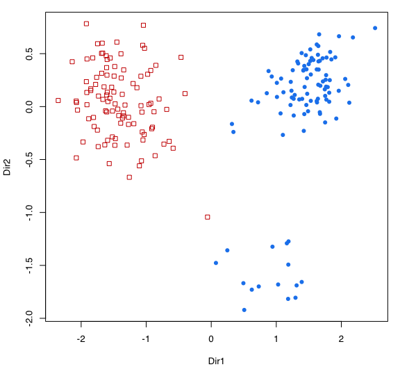

```r
plot(mod3dr, what = "scatterplot")
```

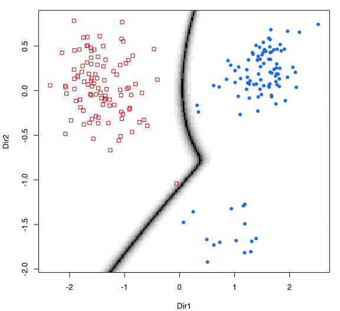

```r
plot(mod3dr, what = "boundaries", ngrid = 200)
```

# Using colorblind-friendly palettes

Most of the graphs produced by **mclust** use colors that by default are defined in the following options:

```r
mclust.options("bicPlotColors")
```

```
##       EII       VII       EEI       EVI       VEI       VVI       EEE
##    "gray"   "black" "#218B21" "#41884F" "#508476" "#58819C" "#597DC3"
##       EVE       VEE       VVE       EEV       VEV       EVV       VVV
## "#5178EA" "#716EE7" "#9B60B8" "#B2508B" "#C03F60" "#C82A36" "#CC0000"
##         E         V
##    "gray"   "black"
```

```r
mclust.options("classPlotColors")
```

```
##  [1] "dodgerblue2"    "red3"           "green3"         "slateblue"
##  [5] "darkorange"     "skyblue1"       "violetred4"     "forestgreen"
##  [9] "steelblue4"     "slategrey"      "brown"          "black"
## [13] "darkseagreen"   "darkgoldenrod3" "olivedrab"      "royalblue"
## [17] "tomato4"        "cyan2"          "springgreen2"
```

The first option controls colors used for plotting BIC, ICL, etc. curves, whereas the second option is used to assign colors for indicating clusters or classes when plotting data.

Color-blind-friendly palettes can be defined and assigned to the above options as follows:

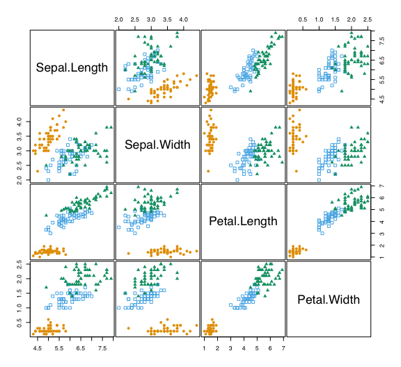

```r
cbPalette <- c("#E69F00", "#56B4E9", "#009E73", "#999999", "#F0E442", "#0072B2", "#D55E00", "#CC79A7")
bicPlotColors <- mclust.options("bicPlotColors")
bicPlotColors[1:14] <- c(cbPalette, cbPalette[1:6])
mclust.options("bicPlotColors" = bicPlotColors)
mclust.options("classPlotColors" = cbPalette)

clPairs(iris[,-5], iris$Species)
```

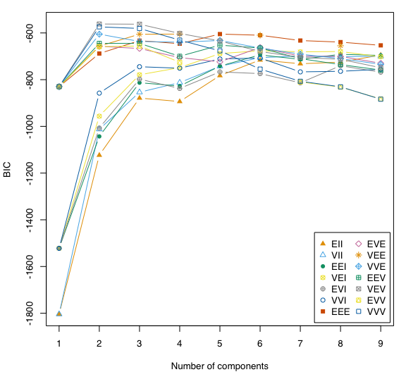

```r
mod <- Mclust(iris[,-5])
plot(mod, what = "BIC")
```

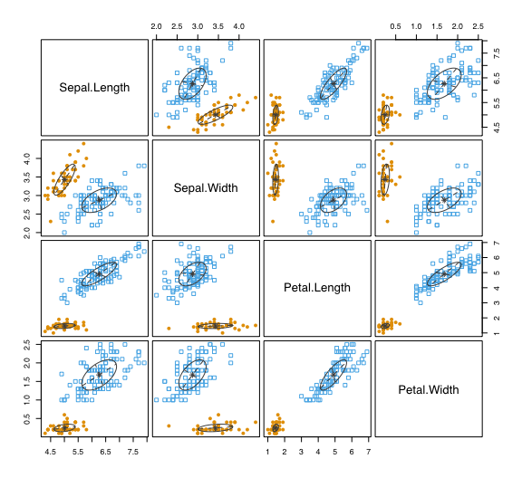

```r
plot(mod, what = "classification")
```

The above color definitions are adapted from http://www.cookbook-r.com/Graphs/Colors_(ggplot2)/, but users can easily define their own palettes if needed.

# References

Scrucca L., Fop M., Murphy T. B. and Raftery A. E. (2016) mclust 5: clustering, classification and density estimation using Gaussian finite mixture models, *The R Journal*, 8/1, pp. 205-233. https://journal.r-project.org/archive/2016/RJ-2016-021/RJ-2016-021.pdf

Fraley C. and Raftery A. E. (2002) Model-based clustering, discriminant analysis and density estimation, *Journal of the American Statistical Association*, 97/458, pp. 611-631.

Fraley C., Raftery A. E., Murphy T. B. and Scrucca L. (2012) mclust Version 4 for R: Normal Mixture Modeling for Model-Based Clustering, Classification, and Density Estimation. *Technical Report* No. 597, Department of Statistics, University of Washington.